# R and SQL

Author

Corey Sparks

Published

August 29, 2022

## Starting Out: Introduction to SQL and Relational Databases

SQL is a language designed for a very specific purpose: to interact with relational databases.

- **Database**: A database is a structured collection of data. There are various different ways of structuring the database, and there may or may not be information about the relationship between entities in the database.
- **Query**: A query is a request for data from the database.
- **Database Management System (DBMS)**: A DBMS is a system of storing and managing databases, including querying the database.
- **Relational Database Management System (RDBMS)**: In an RDBMS, data records are stored in *tables*, each of which has a predefined set of *columns*, the pieces of information captured for each record in a table, and *rows* in the table, where each row has a place to store a value for every column in the table.

Tables, including their columns, column types and relationships with other tables, are defined in a database **schema**. Many times, tables will contain a **primary key**, one or more columns that uniquely define a row. You can think of the primary key as a kind of ID, in which each row is given a unique ID. Tables can also contain **foreign keys**, which are column(s) that comprise the primary key in another table and, thus, provides a way of matching between multiple tables.

In this workbook, we will be using 2019 American Community Survey Public Use Microdata (PUMS). These are public-use data sets containing information about responses to the Census Bureau American Community Survey.

These are public-use data sets containing information about responses to the Census Bureau American Community Survey. Information about the ACS project can be found [here](https://www.census.gov/programs-surveys/acs).

We will be using the ACS PUMS dataset for Texas and California in our examples in this workbook.

You can find more information about the ACS datasets [here](https://www.census.gov/programs-surveys/acs/microdata/access.2019.html) and the codebook for the data [here](https://github.com/coreysparks/data/blob/master/pums_vars.xlsx?raw=true). The codebook will show you the names of the variables in the data and a description of them.

Go to this site and download the database: https://drive.google.com/file/d/14Kwex8x3IPEGOLIP_lS3CXeU5iDB1cK1/view?usp=sharing

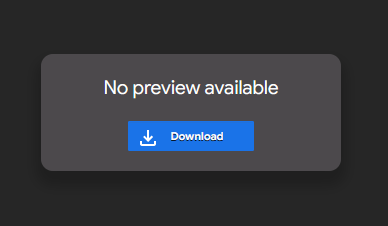

and save it to your local computer. I recommend putting the file *PUMS_data* in the User folder on your computer.

## Writing a Basic Query

In order to analyze the data in a database, we need to query it, or request specific information about the data. Before we do that, run the following cell to establish a connection to the database.

In R we use a couple of libraries to do this. You will need to install the `DBI` and `RSQLite` packages first.

```r
library(tidyverse)
library(DBI)
library(RSQLite)
```

Next we establish the connection to our database. You will need to change the path of the file to the location on your computer where you downloaded the data.

```r
con <-dbConnect(SQLite(),
                dbname = "C:/Users/ozd504/OneDrive - University of Texas at San Antonio/excelencia_course/PUMS_data")
con
```

```
<SQLiteConnection>
  Path: C:\Users\ozd504\OneDrive - University of Texas at San Antonio\excelencia_course\PUMS_data
  Extensions: TRUE
```

To see the tables in the connected database, use the `dbListTables()` function.

```r
dbListTables(con)
```

```
[1] "pums_hh_vars_csv"   "pums_tx_ca"         "pums_tx_ca_2019"
[4] "pums_tx_ca_hh"      "pums_tx_ca_hh_2019" "pums_vars_csv"
```

Now we are ready to do our first query from the data. We want to query the first 10 rows of the `pums_tx_ca` table.

```r
dbGetQuery(con,
  'SELECT * FROM pums_tx_ca
   LIMIT 10;')
```

| SERIALNO | SPORDER | WGTP | PWGTP | AGEP | WAGP | ST | TYPE | SCHL | SEX | ESR | FOD1P | HISP | OCCP | RAC1P | ST_label | TYPE_label | SCHL_label | SEX_label | ESR_label | FOD1P_label | HISP_label | OCCP_label | RAC1P_label |
| --- | --- | --- | --- | --- | --- | --- | --- | --- | --- | --- | --- | --- | --- | --- | --- | --- | --- | --- | --- | --- | --- | --- | --- |
| 2019HU0000003 | 1 | 65 | 64 | 42 | 75000 | 48 | 1 | 22 | 1 | 1 | 2102 | 1 | 1010 | 6 | Texas/TX | Housing unit | Master's degree | Male | Civilian employed, at work | Computer Science | Not Spanish/Hispanic/Latino | CMM-Computer Programmers | Asian alone |
| 2019HU0000003 | 2 | 65 | 44 | 35 | 0 | 48 | 1 | 21 | 2 | 6 | 6000 | 1 | 9 | 6 | Texas/TX | Housing unit | Bachelor's degree | Female | Not in labor force | Fine Arts | Not Spanish/Hispanic/Latino | NA | Asian alone |
| 2019HU0000003 | 3 | 65 | 67 | 9 | -1 | 48 | 1 | 07 | 2 | b | 1099 | 1 | 9 | 6 | Texas/TX | Housing unit | Grade 4 | Female | N/A (less than 16 years old) | NA | Not Spanish/Hispanic/Latino | NA | Asian alone |
| 2019HU0000003 | 4 | 65 | 67 | 8 | -1 | 48 | 1 | 06 | 2 | b | 1099 | 1 | 9 | 6 | Texas/TX | Housing unit | Grade 3 | Female | N/A (less than 16 years old) | NA | Not Spanish/Hispanic/Latino | NA | Asian alone |
| 2019HU0000003 | 5 | 65 | 69 | 0 | -1 | 48 | 1 | bb | 2 | b | 1099 | 1 | 9 | 6 | Texas/TX | Housing unit | N/A (less than 3 years old) | Female | N/A (less than 16 years old) | NA | Not Spanish/Hispanic/Latino | NA | Asian alone |
| 2019HU0000016 | 1 | 112 | 111 | 27 | 34800 | 6 | 1 | 21 | 2 | 1 | 1902 | 2 | 120 | 8 | California/CA | Housing unit | Bachelor's degree | Female | Civilian employed, at work | Journalism | Mexican | MGR-Financial Managers | Some Other Race alone |
| 2019HU0000016 | 2 | 112 | 137 | 33 | 0 | 6 | 1 | 16 | 2 | 3 | 1099 | 2 | 5820 | 8 | California/CA | Housing unit | Regular high school diploma | Female | Unemployed | NA | Mexican | OFF-Word Processors And Typists | Some Other Race alone |
| 2019HU0000016 | 3 | 112 | 107 | 24 | 0 | 6 | 1 | 16 | 2 | 6 | 1099 | 2 | 9 | 8 | California/CA | Housing unit | Regular high school diploma | Female | Not in labor force | NA | Mexican | NA | Some Other Race alone |
| 2019HU0000023 | 1 | 46 | 46 | 55 | 0 | 48 | 1 | 21 | 1 | 1 | 5506 | 1 | 4810 | 1 | Texas/TX | Housing unit | Bachelor's degree | Male | Civilian employed, at work | Political Science And Government | Not Spanish/Hispanic/Latino | SAL-Insurance Sales Agents | White alone |
| 2019HU0000023 | 2 | 46 | 51 | 56 | 38000 | 48 | 1 | 19 | 2 | 1 | 1099 | 2 | 5240 | 5 | Texas/TX | Housing unit | 1 or more years of college credit, no degree | Female | Civilian employed, at work | NA | Mexican | OFF-Customer Service Representatives | American Indian and Alaska Native tribes specified; or American Indian or Alaska Native, not specified and no other races |

**SELECT:** We start out with the `SELECT` statement. The `SELECT` statement specifies which variables (columns) you want. - Here, we used `SELECT *`. The “`*`” just says that we want all the variables. - If we wanted a few columns, we would use the column names separated by commas instead of “`*`” (for example, `AGEP, SEX, ST`).

- **FROM:** Now, let’s look at the next part of the query, `FROM pums_tx_ca`. This part of the query specifies the table, `pums_tx_ca`, from which we want to retrieve the data. Most of your queries will begin in this fashion, describing which columns you want and from which table.
- **LIMIT:** We typically include a `LIMIT` statement at the end of our query so that we don’t get overloaded with rows being output. Here, `LIMIT 10` means that we just want the first ten rows. Many times, the `LIMIT` that you want will be higher than 10 – you might generally prefer to use 1000 or so. Having a `LIMIT` for all queries is highly recommended even if you know only a few rows will be shown, since it acts as a safety precaution against (for example) displaying millions of rows of data.

In this case, we’ve put everything in one line, but that’s not necessary. We could have split the code up into multiple lines, like so:

```
SELECT *
FROM pums_tx_ca
LIMIT 10;
```

This gives the same output as our original query. Generally, once queries start getting longer, breaking up the code into multiple lines can be very helpful in organizing your code and making it easier to read.

Along those lines, note that we used a semi-colon at the end of the query to mark the end of the query. That isn’t absolutely necessary here, but it does help mark the end of a query and is required in other applications of SQL, so it’s good practice to use it.

### Side note about capitalization

> If you notice, we’ve been using all caps for SQL commands and all lowercase for data table and schema names. This is simply a convention, as SQL is not case sensitive. For example, we could have run `select * from pums_tx_ca limit 10;` and it would have given us the exact same output as the first query.

Now, consider the following query. What do you think it will do?

```
SELECT AGEP, ST
FROM pums_tx_ca
LIMIT 10;
```

```r
dbGetQuery(con,
  'SELECT AGEP, ST FROM pums_tx_ca
   LIMIT 10;')
```

| AGEP | ST |
| --- | --- |
| 42 | 48 |
| 35 | 48 |
| 9 | 48 |
| 8 | 48 |
| 0 | 48 |
| 27 | 6 |
| 33 | 6 |
| 24 | 6 |
| 55 | 48 |
| 56 | 48 |

## Checkpoint 1: Running Basic Queries

Consider the following queries. What do you think they will do? Try figuring out what the output will look like, then run the code to see if you’re correct.

- `SELECT * FROM pums_tx_ca LIMIT 25;`
- `SELECT SCHL, SEX, HISP, OCCP FROM pums_tx_ca LIMIT 1000;`
- `SELECT * FROM pums_tx_ca_hh LIMIT 100;`

Think about the following scenarios. What is the query you would use to answer these questions? Try them out.

- You want to see the first 100 rows of the variables containing informatoin on respondent’s race and wages variables.

## Checking Number of Rows and Duplicates

Let’s say we want to find out how many rows there are. You can do this by using a `COUNT`.

```r
dbGetQuery(con,
  'SELECT COUNT(*)
  FROM pums_tx_ca;')
```

| COUNT(*) |
| --- |
| 625899 |

Here, we used `COUNT(*)`, which does a count of all rows, regardless of `NULL` values. We can instead do a count of all non-`NULL` values of a certain variable by including that variable instead of `*`.

```r
dbGetQuery(con,
  'SELECT COUNT(ST)
  FROM pums_tx_ca;')
```

| COUNT(ST) |
| --- |
| 625899 |

But wait; what if there are duplicates in the data? We can check for them by using `DISTINCT`.

```r
dbGetQuery(con,
  'SELECT DISTINCT(ST)
  FROM pums_tx_ca;')
```

| ST |
| --- |
| 48 |
| 6 |

And we see there are 2 states in the data.

This shows us all of the rows with distinct `ST` values; that is, all of the distinct state ids. Let’s count how many there are. To count them, all we have to do is put `COUNT()` around the `DISTINCT` part.

```r
dbGetQuery(con,
  'SELECT COUNT ( DISTINCT ( ST ) )
  FROM pums_tx_ca;')
```

| COUNT ( DISTINCT ( ST ) ) |
| --- |
| 2 |

### Building Up a Query

> Notice that we wanted to count the number of distinct rows, but we first started from querying the rows with distinct `ST` first before adding in the `COUNT`. Though this is a simple example, this process of building up a query as we go is important, especially when we get to more complicated tasks. When writing a query, try to think about the basic parts first, and feel free to run intermediate steps (making sure to include `LIMIT`) as you go.

## Using Conditional Statements

Suppose we want to look at a subset of the data. We can use conditional statements to do this.

```r
dbGetQuery(con,
  'SELECT *
  FROM pums_tx_ca
  WHERE AGEP > 18
  LIMIT 10;')
```

| SERIALNO | SPORDER | WGTP | PWGTP | AGEP | WAGP | ST | TYPE | SCHL | SEX | ESR | FOD1P | HISP | OCCP | RAC1P | ST_label | TYPE_label | SCHL_label | SEX_label | ESR_label | FOD1P_label | HISP_label | OCCP_label | RAC1P_label |
| --- | --- | --- | --- | --- | --- | --- | --- | --- | --- | --- | --- | --- | --- | --- | --- | --- | --- | --- | --- | --- | --- | --- | --- |
| 2019HU0000003 | 1 | 65 | 64 | 42 | 75000 | 48 | 1 | 22 | 1 | 1 | 2102 | 1 | 1010 | 6 | Texas/TX | Housing unit | Master's degree | Male | Civilian employed, at work | Computer Science | Not Spanish/Hispanic/Latino | CMM-Computer Programmers | Asian alone |
| 2019HU0000003 | 2 | 65 | 44 | 35 | 0 | 48 | 1 | 21 | 2 | 6 | 6000 | 1 | 9 | 6 | Texas/TX | Housing unit | Bachelor's degree | Female | Not in labor force | Fine Arts | Not Spanish/Hispanic/Latino | NA | Asian alone |
| 2019HU0000016 | 1 | 112 | 111 | 27 | 34800 | 6 | 1 | 21 | 2 | 1 | 1902 | 2 | 120 | 8 | California/CA | Housing unit | Bachelor's degree | Female | Civilian employed, at work | Journalism | Mexican | MGR-Financial Managers | Some Other Race alone |
| 2019HU0000016 | 2 | 112 | 137 | 33 | 0 | 6 | 1 | 16 | 2 | 3 | 1099 | 2 | 5820 | 8 | California/CA | Housing unit | Regular high school diploma | Female | Unemployed | NA | Mexican | OFF-Word Processors And Typists | Some Other Race alone |
| 2019HU0000016 | 3 | 112 | 107 | 24 | 0 | 6 | 1 | 16 | 2 | 6 | 1099 | 2 | 9 | 8 | California/CA | Housing unit | Regular high school diploma | Female | Not in labor force | NA | Mexican | NA | Some Other Race alone |
| 2019HU0000023 | 1 | 46 | 46 | 55 | 0 | 48 | 1 | 21 | 1 | 1 | 5506 | 1 | 4810 | 1 | Texas/TX | Housing unit | Bachelor's degree | Male | Civilian employed, at work | Political Science And Government | Not Spanish/Hispanic/Latino | SAL-Insurance Sales Agents | White alone |
| 2019HU0000023 | 2 | 46 | 51 | 56 | 38000 | 48 | 1 | 19 | 2 | 1 | 1099 | 2 | 5240 | 5 | Texas/TX | Housing unit | 1 or more years of college credit, no degree | Female | Civilian employed, at work | NA | Mexican | OFF-Customer Service Representatives | American Indian and Alaska Native tribes specified; or American Indian or Alaska Native, not specified and no other races |
| 2019HU0000026 | 1 | 87 | 88 | 21 | 28800 | 6 | 1 | 06 | 2 | 1 | 1099 | 2 | 4030 | 8 | California/CA | Housing unit | Grade 3 | Female | Civilian employed, at work | NA | Mexican | EAT-Food Preparation Workers | Some Other Race alone |
| 2019HU0000026 | 4 | 87 | 124 | 44 | 25900 | 6 | 1 | 01 | 2 | 1 | 1099 | 2 | 4020 | 8 | California/CA | Housing unit | No schooling completed | Female | Civilian employed, at work | NA | Mexican | EAT-Cooks | Some Other Race alone |
| 2019HU0000068 | 1 | 56 | 56 | 25 | 13600 | 48 | 1 | 21 | 2 | 1 | 4101 | 1 | 725 | 1 | Texas/TX | Housing unit | Bachelor's degree | Female | Civilian employed, at work | Physical Fitness Parks Recreation And Leisure | Not Spanish/Hispanic/Latino | BUS-Meeting, Convention, And Event Planners | White alone |

Using a query like the one above can be useful for finding if there are any data entry errors or missing values. Since it’s not possible to have an age less 0, if there are any rows with negative age, this is likely an error or the method used to code missing values (e.g. `-1`).

We can also use more complicated conditional statements.

```r
dbGetQuery(con,
  'SELECT *
  FROM pums_tx_ca
  WHERE AGEP > 18 AND AGEP <65
  LIMIT 10;')
```

| SERIALNO | SPORDER | WGTP | PWGTP | AGEP | WAGP | ST | TYPE | SCHL | SEX | ESR | FOD1P | HISP | OCCP | RAC1P | ST_label | TYPE_label | SCHL_label | SEX_label | ESR_label | FOD1P_label | HISP_label | OCCP_label | RAC1P_label |
| --- | --- | --- | --- | --- | --- | --- | --- | --- | --- | --- | --- | --- | --- | --- | --- | --- | --- | --- | --- | --- | --- | --- | --- |
| 2019HU0000003 | 1 | 65 | 64 | 42 | 75000 | 48 | 1 | 22 | 1 | 1 | 2102 | 1 | 1010 | 6 | Texas/TX | Housing unit | Master's degree | Male | Civilian employed, at work | Computer Science | Not Spanish/Hispanic/Latino | CMM-Computer Programmers | Asian alone |
| 2019HU0000003 | 2 | 65 | 44 | 35 | 0 | 48 | 1 | 21 | 2 | 6 | 6000 | 1 | 9 | 6 | Texas/TX | Housing unit | Bachelor's degree | Female | Not in labor force | Fine Arts | Not Spanish/Hispanic/Latino | NA | Asian alone |
| 2019HU0000016 | 1 | 112 | 111 | 27 | 34800 | 6 | 1 | 21 | 2 | 1 | 1902 | 2 | 120 | 8 | California/CA | Housing unit | Bachelor's degree | Female | Civilian employed, at work | Journalism | Mexican | MGR-Financial Managers | Some Other Race alone |
| 2019HU0000016 | 2 | 112 | 137 | 33 | 0 | 6 | 1 | 16 | 2 | 3 | 1099 | 2 | 5820 | 8 | California/CA | Housing unit | Regular high school diploma | Female | Unemployed | NA | Mexican | OFF-Word Processors And Typists | Some Other Race alone |
| 2019HU0000016 | 3 | 112 | 107 | 24 | 0 | 6 | 1 | 16 | 2 | 6 | 1099 | 2 | 9 | 8 | California/CA | Housing unit | Regular high school diploma | Female | Not in labor force | NA | Mexican | NA | Some Other Race alone |
| 2019HU0000023 | 1 | 46 | 46 | 55 | 0 | 48 | 1 | 21 | 1 | 1 | 5506 | 1 | 4810 | 1 | Texas/TX | Housing unit | Bachelor's degree | Male | Civilian employed, at work | Political Science And Government | Not Spanish/Hispanic/Latino | SAL-Insurance Sales Agents | White alone |
| 2019HU0000023 | 2 | 46 | 51 | 56 | 38000 | 48 | 1 | 19 | 2 | 1 | 1099 | 2 | 5240 | 5 | Texas/TX | Housing unit | 1 or more years of college credit, no degree | Female | Civilian employed, at work | NA | Mexican | OFF-Customer Service Representatives | American Indian and Alaska Native tribes specified; or American Indian or Alaska Native, not specified and no other races |
| 2019HU0000026 | 1 | 87 | 88 | 21 | 28800 | 6 | 1 | 06 | 2 | 1 | 1099 | 2 | 4030 | 8 | California/CA | Housing unit | Grade 3 | Female | Civilian employed, at work | NA | Mexican | EAT-Food Preparation Workers | Some Other Race alone |
| 2019HU0000026 | 4 | 87 | 124 | 44 | 25900 | 6 | 1 | 01 | 2 | 1 | 1099 | 2 | 4020 | 8 | California/CA | Housing unit | No schooling completed | Female | Civilian employed, at work | NA | Mexican | EAT-Cooks | Some Other Race alone |
| 2019HU0000068 | 1 | 56 | 56 | 25 | 13600 | 48 | 1 | 21 | 2 | 1 | 4101 | 1 | 725 | 1 | Texas/TX | Housing unit | Bachelor's degree | Female | Civilian employed, at work | Physical Fitness Parks Recreation And Leisure | Not Spanish/Hispanic/Latino | BUS-Meeting, Convention, And Event Planners | White alone |

This subsets to rows in which AGEP is greater than 18 and AGEP is less than 65. That is, this subsets to people with ages between 18 and 65. Using OR works in the same way.

```r
dbGetQuery(con,
  'SELECT *
  FROM pums_tx_ca
  WHERE AGEP > 18  OR AGEP <65
  LIMIT 10;')
```

| SERIALNO | SPORDER | WGTP | PWGTP | AGEP | WAGP | ST | TYPE | SCHL | SEX | ESR | FOD1P | HISP | OCCP | RAC1P | ST_label | TYPE_label | SCHL_label | SEX_label | ESR_label | FOD1P_label | HISP_label | OCCP_label | RAC1P_label |
| --- | --- | --- | --- | --- | --- | --- | --- | --- | --- | --- | --- | --- | --- | --- | --- | --- | --- | --- | --- | --- | --- | --- | --- |
| 2019HU0000003 | 1 | 65 | 64 | 42 | 75000 | 48 | 1 | 22 | 1 | 1 | 2102 | 1 | 1010 | 6 | Texas/TX | Housing unit | Master's degree | Male | Civilian employed, at work | Computer Science | Not Spanish/Hispanic/Latino | CMM-Computer Programmers | Asian alone |
| 2019HU0000003 | 2 | 65 | 44 | 35 | 0 | 48 | 1 | 21 | 2 | 6 | 6000 | 1 | 9 | 6 | Texas/TX | Housing unit | Bachelor's degree | Female | Not in labor force | Fine Arts | Not Spanish/Hispanic/Latino | NA | Asian alone |
| 2019HU0000003 | 3 | 65 | 67 | 9 | -1 | 48 | 1 | 07 | 2 | b | 1099 | 1 | 9 | 6 | Texas/TX | Housing unit | Grade 4 | Female | N/A (less than 16 years old) | NA | Not Spanish/Hispanic/Latino | NA | Asian alone |
| 2019HU0000003 | 4 | 65 | 67 | 8 | -1 | 48 | 1 | 06 | 2 | b | 1099 | 1 | 9 | 6 | Texas/TX | Housing unit | Grade 3 | Female | N/A (less than 16 years old) | NA | Not Spanish/Hispanic/Latino | NA | Asian alone |
| 2019HU0000003 | 5 | 65 | 69 | 0 | -1 | 48 | 1 | bb | 2 | b | 1099 | 1 | 9 | 6 | Texas/TX | Housing unit | N/A (less than 3 years old) | Female | N/A (less than 16 years old) | NA | Not Spanish/Hispanic/Latino | NA | Asian alone |
| 2019HU0000016 | 1 | 112 | 111 | 27 | 34800 | 6 | 1 | 21 | 2 | 1 | 1902 | 2 | 120 | 8 | California/CA | Housing unit | Bachelor's degree | Female | Civilian employed, at work | Journalism | Mexican | MGR-Financial Managers | Some Other Race alone |
| 2019HU0000016 | 2 | 112 | 137 | 33 | 0 | 6 | 1 | 16 | 2 | 3 | 1099 | 2 | 5820 | 8 | California/CA | Housing unit | Regular high school diploma | Female | Unemployed | NA | Mexican | OFF-Word Processors And Typists | Some Other Race alone |
| 2019HU0000016 | 3 | 112 | 107 | 24 | 0 | 6 | 1 | 16 | 2 | 6 | 1099 | 2 | 9 | 8 | California/CA | Housing unit | Regular high school diploma | Female | Not in labor force | NA | Mexican | NA | Some Other Race alone |
| 2019HU0000023 | 1 | 46 | 46 | 55 | 0 | 48 | 1 | 21 | 1 | 1 | 5506 | 1 | 4810 | 1 | Texas/TX | Housing unit | Bachelor's degree | Male | Civilian employed, at work | Political Science And Government | Not Spanish/Hispanic/Latino | SAL-Insurance Sales Agents | White alone |
| 2019HU0000023 | 2 | 46 | 51 | 56 | 38000 | 48 | 1 | 19 | 2 | 1 | 1099 | 2 | 5240 | 5 | Texas/TX | Housing unit | 1 or more years of college credit, no degree | Female | Civilian employed, at work | NA | Mexican | OFF-Customer Service Representatives | American Indian and Alaska Native tribes specified; or American Indian or Alaska Native, not specified and no other races |

This subsets to rows in which `AGEP` is greater than 18 or less than 65.

### Common Comparison Operators

> ```
>    SELECT count(*)
>    FROM pums_tx_ca
>    WHERE WAGP IS NULL;
> ```

## Creating Variables

Suppose we want to create a new column in the table that acts as a “flag” for which rows fit a certain condition, so that you can use them later. We can do this using the `ALTER TABLE` statement.

```r
dbExecute(con,
  'ALTER TABLE pums_tx_ca
  ADD over65 BOOL;')
```

```
[1] 0
```

```r
dbExecute(con,
  'UPDATE pums_tx_ca SET over65 = 0;')
```

```
[1] 625899
```

```r
dbExecute(con,
  'UPDATE pums_tx_ca SET over65 = 1 WHERE AGEP > 65;')
```

```
[1] 105882
```

```r
dbGetQuery(con,
 'select over65, AGEP,ST from pums_tx_ca
 limit 10;')
```

| over65 | AGEP | ST |
| --- | --- | --- |
| 0 | 42 | 48 |
| 0 | 35 | 48 |
| 0 | 9 | 48 |
| 0 | 8 | 48 |
| 0 | 0 | 48 |
| 0 | 27 | 6 |
| 0 | 33 | 6 |
| 0 | 24 | 6 |
| 0 | 55 | 48 |
| 0 | 56 | 48 |

Let’s break this down line by line. First, we use `ALTER TABLE`, then specify the table we want to alter. In this case, we want to alter the `pums_tx_ca` table. Then, we `ADD` a new column, `over65`. We designate this as a `BOOL` for boolean (that is, a TRUE/FALSE value) column.

After we create this new column, we need to fill it with the appropriate values. First, we’re going to set everything in the column to be 0 (or False). To do this, we use `UPDATE`, specify the appropriate table, then use `SET over65 = 0`.

Then, we replace the value with 1 (or True) if the value in `AGEP` for that row is above 65. We again use `UPDATE` in a similar manner, except we add a `WHERE` clause, so that it only set the value to TRUE if a certain condition is met – in this case, that `AGEP > 65`.

## Using Aggregation Functions

We’ve created a variable that indicates whether the person’s age is over 65 or not. What if we wanted to know how many people were over 65 and how many weren’t? We can now use the `GROUP BY` statement.

```r
dbGetQuery(con,
  'SELECT over65, COUNT(over65)
  FROM pums_tx_ca
  GROUP BY over65;')
```

| over65 | COUNT(over65) |
| --- | --- |
| 0 | 520017 |
| 1 | 105882 |

Here, the `GROUP BY` statement groups it into the categories of the variable. Since we’ve chosen to display the count, we can see the counts. We can also change the order in which the results are displayed so that it’s in increasing order.

```r
dbGetQuery(con,
  'SELECT over65, COUNT(over65)
  FROM pums_tx_ca
  GROUP BY over65
  ORDER BY COUNT(over65);')
```

| over65 | COUNT(over65) |
| --- | --- |
| 1 | 105882 |
| 0 | 520017 |

### Using GROUP BY with Multiple Variables

For the next few queries, let’s try using a different table. The `pums_tx_ca_hh` table in the same `PUMS_data` database contains information about households that each person lives in. We can use this to, for example, look at how many households do not have access to the internet by state. *NOTE* ACCESS values of 3 indicate that a house has no access to the internet

```r
dbGetQuery(con,
  'SELECT ACCESS,ST, COUNT(*)
  FROM pums_tx_ca_hh
  GROUP BY ACCESS, ST
  ORDER BY ACCESS DESC;')
```

| ACCESS | ST | COUNT(*) |
| --- | --- | --- |
| 3 | 6 | 9521 |
| 3 | 48 | 10677 |
| 2 | 6 | 2445 |
| 2 | 48 | 2294 |
| 1 | 6 | 123642 |
| 1 | 48 | 90169 |

This first groups by ACCESS (`ACCESS`) name, then it groups by state (`ST`), in that order.

Further, notice that we used `DESC` after `ORDER BY`. This orders in descending order instead of ascending order, so that we can see the areas with the highest values of `ACCESS` at the top.

### Conditional Statements After Aggregation

Suppose we wanted to display only certain counts. We can use `HAVING` to do this.

```r
dbGetQuery(con,
  'SELECT ACCESS,ST, COUNT(*)
  FROM pums_tx_ca_hh
  GROUP BY ACCESS, ST
  HAVING ACCESS = 3
  ORDER BY ACCESS DESC;')
```

| ACCESS | ST | COUNT(*) |
| --- | --- | --- |
| 3 | 6 | 9521 |
| 3 | 48 | 10677 |

This displays on the numbers of households that don’t have internet access.

### Using Different Aggregation Functions

What if we wanted to find the sum within each group, or the minimum or maximum value? We can use the appropriate aggregation function. To show this, let’s go back to our `pums_tx_ca` table.

```r
dbGetQuery(con,
  'SELECT over65, SEX_label, COUNT(over65), AVG(WAGP) AS avg_wage, MIN(WAGP), MAX(WAGP)
  FROM pums_tx_ca
  WHERE WAGP > 0
  GROUP BY over65, SEX_label
  ORDER BY over65;')
```

| over65 | SEX_label | COUNT(over65) | avg_wage | MIN(WAGP) | MAX(WAGP) |
| --- | --- | --- | --- | --- | --- |
| 0 | Female | 136914 | 49224.06 | 4 | 571000 |
| 0 | Male | 150071 | 72825.69 | 4 | 571000 |
| 1 | Female | 8809 | 39265.85 | 10 | 571000 |
| 1 | Male | 10361 | 71231.26 | 30 | 571000 |

Here, we’re finding the counts, average, minimum, and maximum value of the wages within each group, defined by respondent’s sex and their age group. These aggregation functions can be very useful.

### Side Note: Aliasing

> You may have noticed that we included a part using “`AS`,” followed by a new name, in the first line. When you ran the code, you might have noticed that the column labels were changed to these new names. This is called aliasing, and is done for readability and ease of access. Later on, aliasing will also help us more easily reference tables within the same query.

## Close the data base connection

```
[1] 0
```

# Homework

1) In three sentences or less, describe the steps you would take to connect to a datasource/server in R

2) Write the lines of code you would use to show the first ten lines of a database named *ds_census_unit3* in R

3) Write the lines of code you would use to extract the total number of distinct individuals in the *pums_tx_ca* table, using the **SERIALNO** as the unique identifier for each person

4) Modify question 3 to count the number of distinct persons in the pums_tx_ca table who are over between ages 29 and 40.

# Merging tables

In a basic sense, we are interested in merging tables that contain different kinds of information on the same subjects.

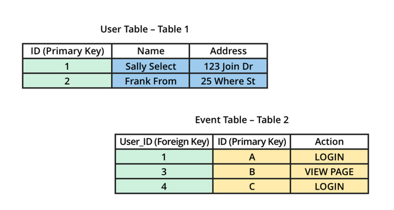

In the ADRF this will be data from *usually* the Survey of Earned Doctorates, the Survey of Doctoral Recipients, the UMETRICS and possibly the IPEDS data.

## Different Types of Joins

There are many ways that we can join tables, and the resulting table will contain different types of records, depending on the join rules we use.

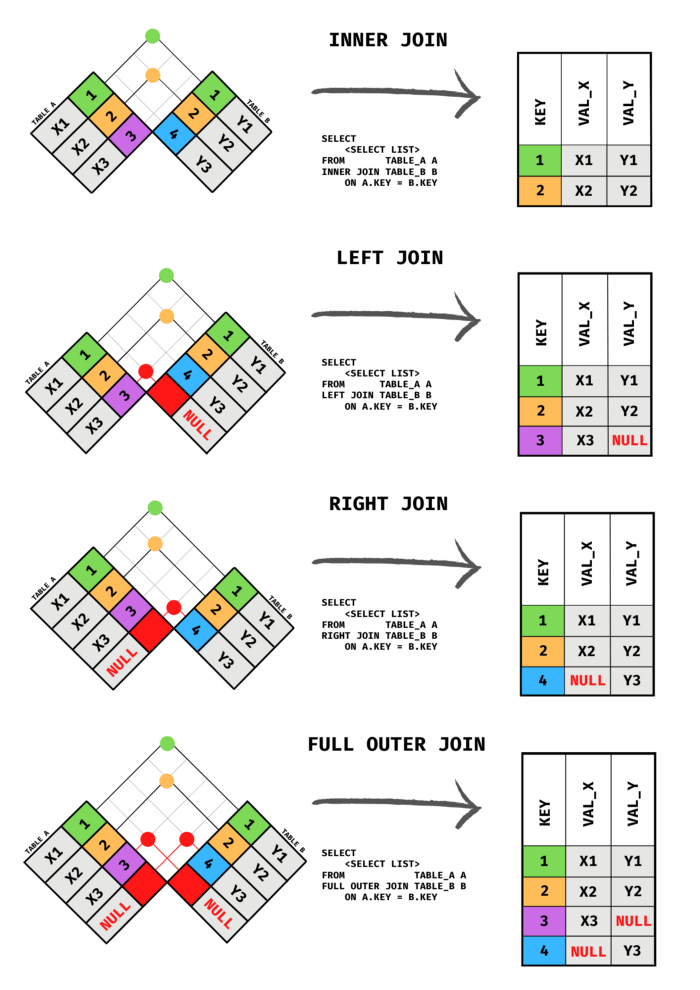

Joins in SQL

### Left Joins

A left join is when you want to combine information from one table (the “left” table) and all information from another table (the “right” table) that matches the key field in the left table.

To do this `JOIN`, we can use the `LEFT JOIN` statement. If the key field has the same name in both tables, you may get an error about “ambiguous column names”, to get around this, you can alias the tables as another name. Below I call the PUMS person table `pums_tx_ca` `x` and the household table `y`.

In the `LEFT JOIN` statement you use the syntax lefttable.key = righttable.key to merge the two tables together.

```r
dbGetQuery(con,
  'SELECT * FROM pums_tx_ca
  LIMIT 10;'
)
```

| SERIALNO | SPORDER | WGTP | PWGTP | AGEP | WAGP | ST | TYPE | SCHL | SEX | ESR | FOD1P | HISP | OCCP | RAC1P | ST_label | TYPE_label | SCHL_label | SEX_label | ESR_label | FOD1P_label | HISP_label | OCCP_label | RAC1P_label |
| --- | --- | --- | --- | --- | --- | --- | --- | --- | --- | --- | --- | --- | --- | --- | --- | --- | --- | --- | --- | --- | --- | --- | --- |
| 2019HU0000003 | 1 | 65 | 64 | 42 | 75000 | 48 | 1 | 22 | 1 | 1 | 2102 | 1 | 1010 | 6 | Texas/TX | Housing unit | Master's degree | Male | Civilian employed, at work | Computer Science | Not Spanish/Hispanic/Latino | CMM-Computer Programmers | Asian alone |
| 2019HU0000003 | 2 | 65 | 44 | 35 | 0 | 48 | 1 | 21 | 2 | 6 | 6000 | 1 | 9 | 6 | Texas/TX | Housing unit | Bachelor's degree | Female | Not in labor force | Fine Arts | Not Spanish/Hispanic/Latino | NA | Asian alone |
| 2019HU0000003 | 3 | 65 | 67 | 9 | -1 | 48 | 1 | 07 | 2 | b | 1099 | 1 | 9 | 6 | Texas/TX | Housing unit | Grade 4 | Female | N/A (less than 16 years old) | NA | Not Spanish/Hispanic/Latino | NA | Asian alone |
| 2019HU0000003 | 4 | 65 | 67 | 8 | -1 | 48 | 1 | 06 | 2 | b | 1099 | 1 | 9 | 6 | Texas/TX | Housing unit | Grade 3 | Female | N/A (less than 16 years old) | NA | Not Spanish/Hispanic/Latino | NA | Asian alone |
| 2019HU0000003 | 5 | 65 | 69 | 0 | -1 | 48 | 1 | bb | 2 | b | 1099 | 1 | 9 | 6 | Texas/TX | Housing unit | N/A (less than 3 years old) | Female | N/A (less than 16 years old) | NA | Not Spanish/Hispanic/Latino | NA | Asian alone |
| 2019HU0000016 | 1 | 112 | 111 | 27 | 34800 | 6 | 1 | 21 | 2 | 1 | 1902 | 2 | 120 | 8 | California/CA | Housing unit | Bachelor's degree | Female | Civilian employed, at work | Journalism | Mexican | MGR-Financial Managers | Some Other Race alone |
| 2019HU0000016 | 2 | 112 | 137 | 33 | 0 | 6 | 1 | 16 | 2 | 3 | 1099 | 2 | 5820 | 8 | California/CA | Housing unit | Regular high school diploma | Female | Unemployed | NA | Mexican | OFF-Word Processors And Typists | Some Other Race alone |
| 2019HU0000016 | 3 | 112 | 107 | 24 | 0 | 6 | 1 | 16 | 2 | 6 | 1099 | 2 | 9 | 8 | California/CA | Housing unit | Regular high school diploma | Female | Not in labor force | NA | Mexican | NA | Some Other Race alone |
| 2019HU0000023 | 1 | 46 | 46 | 55 | 0 | 48 | 1 | 21 | 1 | 1 | 5506 | 1 | 4810 | 1 | Texas/TX | Housing unit | Bachelor's degree | Male | Civilian employed, at work | Political Science And Government | Not Spanish/Hispanic/Latino | SAL-Insurance Sales Agents | White alone |
| 2019HU0000023 | 2 | 46 | 51 | 56 | 38000 | 48 | 1 | 19 | 2 | 1 | 1099 | 2 | 5240 | 5 | Texas/TX | Housing unit | 1 or more years of college credit, no degree | Female | Civilian employed, at work | NA | Mexican | OFF-Customer Service Representatives | American Indian and Alaska Native tribes specified; or American Indian or Alaska Native, not specified and no other races |

```r
dbGetQuery(con,
  'SELECT * FROM pums_tx_ca_hh
  LIMIT 10;'
)
```

| SERIALNO | SPORDER | WGTP | PWGTP | NP | VALP | ST | TYPE | ACCESS | HISPEED | TEN | ST_label | TYPE_label | ACCESS_label | HISPEED_label | TEN_label |
| --- | --- | --- | --- | --- | --- | --- | --- | --- | --- | --- | --- | --- | --- | --- | --- |
| 2019HU0000003 | 1 | 65 | 64 | 5 | 350000 | 48 | 1 | 1 | 1 | 1 | Texas/TX | Housing unit | Yes, by paying a cell phone company or Internet service provider | Yes | Owned with mortgage or loan (include home equity loans) |
| 2019HU0000016 | 1 | 112 | 111 | 3 | -1 | 6 | 1 | 1 | 2 | 3 | California/CA | Housing unit | Yes, by paying a cell phone company or Internet service provider | No | Rented |
| 2019HU0000023 | 1 | 46 | 46 | 2 | 270000 | 48 | 1 | 1 | 1 | 1 | Texas/TX | Housing unit | Yes, by paying a cell phone company or Internet service provider | Yes | Owned with mortgage or loan (include home equity loans) |
| 2019HU0000026 | 1 | 87 | 88 | 4 | -1 | 6 | 1 | 3 | b | 3 | California/CA | Housing unit | No access to the Internet at this house, apartment, or mobile home | N/A (GQ/vacant/no paid access to the internet) | Rented |
| 2019HU0000068 | 1 | 56 | 56 | 2 | 250000 | 48 | 1 | 1 | 1 | 1 | Texas/TX | Housing unit | Yes, by paying a cell phone company or Internet service provider | Yes | Owned with mortgage or loan (include home equity loans) |
| 2019HU0000086 | 1 | 191 | 190 | 4 | 440000 | 48 | 1 | 1 | 1 | 1 | Texas/TX | Housing unit | Yes, by paying a cell phone company or Internet service provider | Yes | Owned with mortgage or loan (include home equity loans) |
| 2019HU0000092 | 1 | 64 | 64 | 5 | 350000 | 6 | 1 | 1 | 1 | 1 | California/CA | Housing unit | Yes, by paying a cell phone company or Internet service provider | Yes | Owned with mortgage or loan (include home equity loans) |
| 2019HU0000119 | 1 | 203 | 203 | 4 | 130000 | 48 | 1 | 1 | 1 | 1 | Texas/TX | Housing unit | Yes, by paying a cell phone company or Internet service provider | Yes | Owned with mortgage or loan (include home equity loans) |
| 2019HU0000134 | 1 | 20 | 20 | 2 | 160000 | 48 | 1 | 1 | 2 | 2 | Texas/TX | Housing unit | Yes, by paying a cell phone company or Internet service provider | No | Owned free and clear |
| 2019HU0000140 | 1 | 292 | 292 | 4 | 420000 | 6 | 1 | 1 | 1 | 1 | California/CA | Housing unit | Yes, by paying a cell phone company or Internet service provider | Yes | Owned with mortgage or loan (include home equity loans) |

```r
dbGetQuery(con,
  'SELECT * FROM pums_tx_ca x
  LEFT JOIN pums_tx_ca_hh y
  ON x.SERIALNO = y.SERIALNO
  LIMIT 100
  ;')
```

| SERIALNO | SPORDER | WGTP | PWGTP | AGEP | WAGP | ST | TYPE | SCHL | SEX | ESR | FOD1P | HISP | OCCP | RAC1P | ST_label | TYPE_label | SCHL_label | SEX_label | ESR_label | FOD1P_label | HISP_label | OCCP_label | RAC1P_label | SERIALNO | SPORDER | WGTP | PWGTP | NP | VALP | … |
| --- | --- | --- | --- | --- | --- | --- | --- | --- | --- | --- | --- | --- | --- | --- | --- | --- | --- | --- | --- | --- | --- | --- | --- | --- | --- | --- | --- | --- | --- | --- |
| 2019HU0000003 | 1 | 65 | 64 | 42 | 75000 | 48 | 1 | 22 | 1 | 1 | 2102 | 1 | 1010 | 6 | Texas/TX | Housing unit | Master's degree | Male | Civilian employed, at work | Computer Science | Not Spanish/Hispanic/Latino | CMM-Computer Programmers | Asian alone | 2019HU0000003 | 1 | 65 | 64 | 5 | 350000 | … |
| 2019HU0000003 | 2 | 65 | 44 | 35 | 0 | 48 | 1 | 21 | 2 | 6 | 6000 | 1 | 9 | 6 | Texas/TX | Housing unit | Bachelor's degree | Female | Not in labor force | Fine Arts | Not Spanish/Hispanic/Latino | NA | Asian alone | 2019HU0000003 | 1 | 65 | 64 | 5 | 350000 | … |
| 2019HU0000003 | 3 | 65 | 67 | 9 | -1 | 48 | 1 | 07 | 2 | b | 1099 | 1 | 9 | 6 | Texas/TX | Housing unit | Grade 4 | Female | N/A (less than 16 years old) | NA | Not Spanish/Hispanic/Latino | NA | Asian alone | 2019HU0000003 | 1 | 65 | 64 | 5 | 350000 | … |
| 2019HU0000003 | 4 | 65 | 67 | 8 | -1 | 48 | 1 | 06 | 2 | b | 1099 | 1 | 9 | 6 | Texas/TX | Housing unit | Grade 3 | Female | N/A (less than 16 years old) | NA | Not Spanish/Hispanic/Latino | NA | Asian alone | 2019HU0000003 | 1 | 65 | 64 | 5 | 350000 | … |
| 2019HU0000003 | 5 | 65 | 69 | 0 | -1 | 48 | 1 | bb | 2 | b | 1099 | 1 | 9 | 6 | Texas/TX | Housing unit | N/A (less than 3 years old) | Female | N/A (less than 16 years old) | NA | Not Spanish/Hispanic/Latino | NA | Asian alone | 2019HU0000003 | 1 | 65 | 64 | 5 | 350000 | … |
| 2019HU0000016 | 1 | 112 | 111 | 27 | 34800 | 6 | 1 | 21 | 2 | 1 | 1902 | 2 | 120 | 8 | California/CA | Housing unit | Bachelor's degree | Female | Civilian employed, at work | Journalism | Mexican | MGR-Financial Managers | Some Other Race alone | 2019HU0000016 | 1 | 112 | 111 | 3 | -1 | … |
| 2019HU0000016 | 2 | 112 | 137 | 33 | 0 | 6 | 1 | 16 | 2 | 3 | 1099 | 2 | 5820 | 8 | California/CA | Housing unit | Regular high school diploma | Female | Unemployed | NA | Mexican | OFF-Word Processors And Typists | Some Other Race alone | 2019HU0000016 | 1 | 112 | 111 | 3 | -1 | … |
| 2019HU0000016 | 3 | 112 | 107 | 24 | 0 | 6 | 1 | 16 | 2 | 6 | 1099 | 2 | 9 | 8 | California/CA | Housing unit | Regular high school diploma | Female | Not in labor force | NA | Mexican | NA | Some Other Race alone | 2019HU0000016 | 1 | 112 | 111 | 3 | -1 | … |
| 2019HU0000023 | 1 | 46 | 46 | 55 | 0 | 48 | 1 | 21 | 1 | 1 | 5506 | 1 | 4810 | 1 | Texas/TX | Housing unit | Bachelor's degree | Male | Civilian employed, at work | Political Science And Government | Not Spanish/Hispanic/Latino | SAL-Insurance Sales Agents | White alone | 2019HU0000023 | 1 | 46 | 46 | 2 | 270000 | … |
| 2019HU0000023 | 2 | 46 | 51 | 56 | 38000 | 48 | 1 | 19 | 2 | 1 | 1099 | 2 | 5240 | 5 | Texas/TX | Housing unit | 1 or more years of college credit, no degree | Female | Civilian employed, at work | NA | Mexican | OFF-Customer Service Representatives | American Indian and Alaska Native tribes specified; or American Indian or Alaska Native, not specified and no other races | 2019HU0000023 | 1 | 46 | 46 | 2 | 270000 | … |

[output cut: 90 more lines]

### Right Joins

These are similar to the left join, but you instead get all matching records that are complete based on the information in the second table instead of the first.

### Outer Join

An outer join keeps all unique ids, then puts `NULL` if it isn’t part of that table. This is similar to a `LEFT` or `RIGHT JOIN`, except instead of only keeping all IDs from one table, it keeps them from both tables. Consider our example with Table A and Table B.In a way, it’s like combining the `LEFT` and `RIGHT JOIN`s so that we have all information from both tables.

# Using `dbplyr` to do queries

R has a very handy way of using our familiar `dplyr` syntax to do SQL queries through the `dbplyr` package. **You will need to install it before you can use it!**

The fundamentals are similar to the syntax above, where we first connect to the database, then we identify the tables in the database we want to work with using the `tbl()` function. The code below connects to the database, then selects the person and household tables:

```r
library(dbplyr)
con <-dbConnect(SQLite(),
                dbname = "C:/Users/ozd504/OneDrive - University of Texas at San Antonio/excelencia_course/PUMS_data")

pums <- tbl(con, "pums_tx_ca")
pums_hh <- tbl(con, "pums_tx_ca_hh")
```

We can now use any of the familiar `dplyr` verbs to select, filter and modify our data. Here is an example where I select some variables, create a new variable using `mutate` and print it.

```r
pums %>%
  select(SERIALNO, AGEP, WAGP)%>%
  mutate(over65 = ifelse(AGEP >= 65, "over 65", "under 65"))
```

| SERIALNO | AGEP | WAGP | over65 |
| --- | --- | --- | --- |
| 2019HU0000003 | 42 | 75000 | under 65 |
| 2019HU0000003 | 35 | 0 | under 65 |
| 2019HU0000003 | 9 | -1 | under 65 |
| 2019HU0000003 | 8 | -1 | under 65 |
| 2019HU0000003 | 0 | -1 | under 65 |
| 2019HU0000016 | 27 | 34800 | under 65 |
| 2019HU0000016 | 33 | 0 | under 65 |
| 2019HU0000016 | 24 | 0 | under 65 |
| 2019HU0000023 | 55 | 0 | under 65 |
| 2019HU0000023 | 56 | 38000 | under 65 |

[output cut: 990 more lines]

What’s even better, is that we can add `show_query()` at the bottom to show us the generated SQL syntax:

```r
pums %>%
  select(SERIALNO, AGEP, WAGP)%>%
  mutate(over65 = ifelse(AGEP >= 65, "over 65", "under 65"))%>%
  show_query()
```

```
<SQL>
SELECT
  `SERIALNO`,
  `AGEP`,
  `WAGP`,
  CASE WHEN (`AGEP` >= 65.0) THEN 'over 65' WHEN NOT (`AGEP` >= 65.0) THEN 'under 65' END AS `over65`
FROM `pums_tx_ca`
```

we can use the `filter()` verb to select cases:

```r
pums %>% select(SERIALNO, AGEP, ST, WAGP)%>%
  filter(AGEP > 18 & AGEP<65, WAGP !=0) %>%
  head(n =10)
```

| SERIALNO | AGEP | ST | WAGP |
| --- | --- | --- | --- |
| 2019HU0000003 | 42 | 48 | 75000 |
| 2019HU0000016 | 27 | 6 | 34800 |
| 2019HU0000023 | 56 | 48 | 38000 |
| 2019HU0000026 | 21 | 6 | 28800 |
| 2019HU0000026 | 44 | 6 | 25900 |
| 2019HU0000068 | 25 | 48 | 13600 |
| 2019HU0000068 | 26 | 48 | 57000 |
| 2019HU0000086 | 38 | 48 | 129000 |
| 2019HU0000092 | 33 | 6 | 107000 |
| 2019HU0000092 | 37 | 6 | 87000 |

We can use the `group_by` and `summarise()` verbs to calculate aggregations for groups:

```r
pums %>% select( SERIALNO, AGEP, ST, WAGP)%>%
  filter(AGEP > 18, WAGP !=0) %>%
  mutate(over65  = ifelse(AGEP >65, 1, 0))%>%
  group_by(ST, over65)%>%
  summarise(avgwage = mean(WAGP),
            medwg = median(WAGP))%>%
  mutate(diff = avgwage - medwg)
```

[output not shown]

| ST | over65 | avgwage | medwg | diff |
| --- | --- | --- | --- | --- |
| 6 | 0 | 66892.72 | 45000 | 21892.72 |
| 6 | 1 | 61428.64 | 32000 | 29428.64 |
| 48 | 0 | 57295.61 | 40000 | 17295.61 |
| 48 | 1 | 50530.78 | 28000 | 22530.78 |

### See the query!

```r
pums %>% select(SERIALNO, AGEP, ST, WAGP)%>%
  filter(AGEP > 18, WAGP !=0) %>%
  mutate(over65  = ifelse(AGEP >65, 1, 0))%>%
  group_by(ST, over65)%>%
  summarise(avgwage = mean(WAGP),
            medwg = median(WAGP),
            samp = n())%>%
  show_query()
```

[output not shown]

```
<SQL>
SELECT
  `ST`,
  `over65`,
  AVG(`WAGP`) AS `avgwage`,
  MEDIAN(`WAGP`) AS `medwg`,
  COUNT(*) AS `samp`
FROM (
  SELECT
    *,
    CASE WHEN (`AGEP` > 65.0) THEN 1.0 WHEN NOT (`AGEP` > 65.0) THEN 0.0 END AS `over65`
  FROM (
    SELECT `SERIALNO`, `AGEP`, `ST`, `WAGP`
    FROM `pums_tx_ca`
  )
  WHERE (`AGEP` > 18.0) AND (`WAGP` != 0.0)
)
GROUP BY `ST`, `over65`
```

### Use the output of the query in graph!

Yes, we can even directly pipe the query result into a ggplot figure.

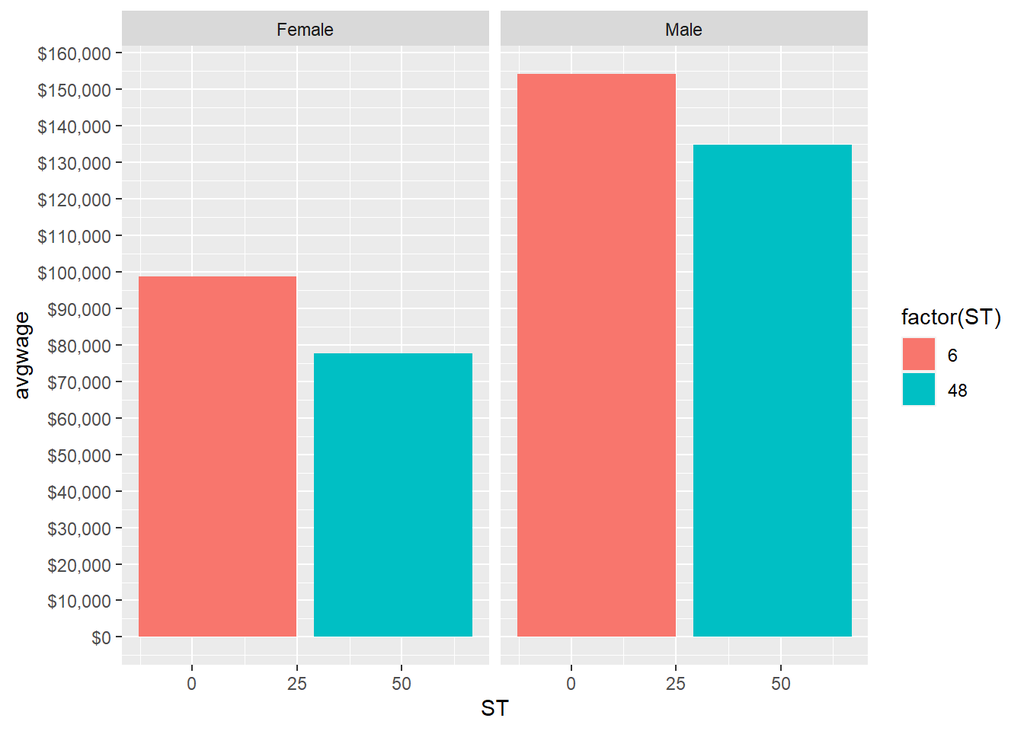

```r
library(ggplot2)
library(scales)
pums %>%
  select(SERIALNO, AGEP, ST,SEX, WAGP)%>%
  filter(AGEP > 18, WAGP !=0) %>%
  mutate(over65  = ifelse(AGEP >65, 1, 0),
         gender = ifelse(SEX ==1 , "Male", "Female"))%>%
  group_by(ST, over65, gender)%>%
  summarise(avgwage = mean(WAGP),
            medwg = median(WAGP),
            samp = n()) %>%
  ggplot()+
  aes(x = ST,
      y = avgwage,
      fill=factor(ST))+
  geom_bar(stat="identity")+
  facet_wrap(~gender) +
  scale_y_continuous(labels = label_dollar(),
                       breaks = seq(0, 160000, 10000))
```

### Saving your query data

The `collect()` verb will take the result of a query and save it as a R dataframe, so you can do other kinds of analysis. Just be sure to store the result in an object!

```r
summ_query <- pums %>%
  select(SERIALNO, AGEP, ST,SEX, WAGP)%>%
  filter(AGEP > 18, WAGP !=0) %>%
  mutate(over65  = ifelse(AGEP >65, 1, 0),
         gender = ifelse(SEX ==1 , "Male", "Female"))%>%
  group_by(ST, over65, gender)%>%
  summarise(avgwage = mean(WAGP),
            medwg = median(WAGP),
            samp = n()) %>%
  collect()
write.csv(summ_query, file = "my great output.csv")

head(summ_query)
```

| ST | over65 | gender | avgwage | medwg | samp |
| --- | --- | --- | --- | --- | --- |
| 6 | 0 | Female | 54789.12 | 38000 | 78675 |
| 6 | 0 | Male | 77910.83 | 50000 | 86426 |
| 6 | 1 | Female | 43820.48 | 24400 | 4809 |
| 6 | 1 | Male | 76114.33 | 41250 | 5766 |
| 48 | 0 | Female | 43915.94 | 32000 | 54917 |
| 48 | 0 | Male | 69529.98 | 50000 | 60058 |

### Joins in dbplyr

You can perform all the same types of joins in `dbplyr` as in normal SQL, these verbs are `left_join`, `right_join` and `outer_join`

```r
pums %>%
  mutate(over65 = ifelse(AGEP >= 65, "over 65", "under 65"))%>%
  select(SERIALNO, AGEP, WAGP, SEX, over65)%>%
  left_join(pums_hh, by = 'SERIALNO' ) %>%
  head()%>%
  show_query()
```

```
<SQL>
SELECT *
FROM (
  SELECT
    `LHS`.`SERIALNO` AS `SERIALNO`,
    `AGEP`,
    `WAGP`,
    `SEX`,
    `over65`,
    `SPORDER`,
    `WGTP`,
    `PWGTP`,
    `NP`,
    `VALP`,
    `ST`,
    `TYPE`,
    `ACCESS`,
    `HISPEED`,
    `TEN`,
    `ST_label`,
    `TYPE_label`,
    `ACCESS_label`,
    `HISPEED_label`,
    `TEN_label`
  FROM (
    SELECT
      `SERIALNO`,
      `AGEP`,
      `WAGP`,
      `SEX`,
      CASE WHEN (`AGEP` >= 65.0) THEN 'over 65' WHEN NOT (`AGEP` >= 65.0) THEN 'under 65' END AS `over65`
    FROM `pums_tx_ca`
  ) AS `LHS`
  LEFT JOIN `pums_tx_ca_hh` AS `RHS`
    ON (`LHS`.`SERIALNO` = `RHS`.`SERIALNO`)
)
LIMIT 6
```

```r
dbDisconnect(con)
```

# Homework - Day 2

Using the ACS tables from above perform the following

1. How many households in Texas had values over $500,000?
2. Create a table of persons in California with less than a High School degree. How many people are in this table?
3. Create a merged table with the columns ST_LABEL, AGEP, RAC1P, WAGP, ACCESS and TENURE for persons in California with less than a bachelor’s degree.